# Introduction

The libraries used in this project are:

1. sklearn
2. matplotlib
3. numpy
4. pandas
5. seaborn

There are different models to train your data, here we will be using:

1. logistic regression
2. decision trees
3. random forest
4. Hyperparameter Tuning method

# Dataset

# Libraries

```python
import os #paths to file
import numpy as np # linear algebra
import pandas as pd # data processing
import warnings# warning filter


#ploting libraries
import matplotlib.pyplot as plt
import seaborn as sns
import warnings# warning filter

#Machine learning libraries
from sklearn.model_selection import train_test_split
from sklearn.metrics import confusion_matrix
from sklearn.metrics import classification_report
from sklearn.metrics import accuracy_score
from sklearn.tree import DecisionTreeClassifier
from sklearn.ensemble import RandomForestClassifier
from sklearn.linear_model import LogisticRegression
warnings.filterwarnings("ignore")
```

# Load the datasets

```python
#load the dataset
#training set
#download the data to run the report
tr_df = pd.read_csv(r"/Users/mirandacheng7/Downloads/Loan Prediction/train_u6lujuX_CVtuZ9i.csv")
#testing set
te_df= pd.read_csv(r"/Users/mirandacheng7/Downloads/Loan Prediction/test_Y3wMUE5_7gLdaTN.csv")
```

# Processing the dataset

##### Take a look at the datesets

Training set:

```python
#display the first 5 rows of the training set
tr_df.head()
```

|  | Loan_ID | Gender | Married | Dependents | Education | Self_Employed | ApplicantIncome | CoapplicantIncome | LoanAmount | Loan_Amount_Term | Credit_History | Property_Area | Loan_Status |
| --- | --- | --- | --- | --- | --- | --- | --- | --- | --- | --- | --- | --- | --- |
| 0 | LP001002 | Male | No | 0 | Graduate | No | 5849 | 0.0 | NaN | 360.0 | 1.0 | Urban | Y |
| 1 | LP001003 | Male | Yes | 1 | Graduate | No | 4583 | 1508.0 | 128.0 | 360.0 | 1.0 | Rural | N |
| 2 | LP001005 | Male | Yes | 0 | Graduate | Yes | 3000 | 0.0 | 66.0 | 360.0 | 1.0 | Urban | Y |
| 3 | LP001006 | Male | Yes | 0 | Not Graduate | No | 2583 | 2358.0 | 120.0 | 360.0 | 1.0 | Urban | Y |
| 4 | LP001008 | Male | No | 0 | Graduate | No | 6000 | 0.0 | 141.0 | 360.0 | 1.0 | Urban | Y |

Testing set:

```python
#display the first 5 rows of the testing set
te_df.head()
```

|  | Loan_ID | Gender | Married | Dependents | Education | Self_Employed | ApplicantIncome | CoapplicantIncome | LoanAmount | Loan_Amount_Term | Credit_History | Property_Area |
| --- | --- | --- | --- | --- | --- | --- | --- | --- | --- | --- | --- | --- |
| 0 | LP001015 | Male | Yes | 0 | Graduate | No | 5720 | 0 | 110.0 | 360.0 | 1.0 | Urban |
| 1 | LP001022 | Male | Yes | 1 | Graduate | No | 3076 | 1500 | 126.0 | 360.0 | 1.0 | Urban |
| 2 | LP001031 | Male | Yes | 2 | Graduate | No | 5000 | 1800 | 208.0 | 360.0 | 1.0 | Urban |
| 3 | LP001035 | Male | Yes | 2 | Graduate | No | 2340 | 2546 | 100.0 | 360.0 | NaN | Urban |
| 4 | LP001051 | Male | No | 0 | Not Graduate | No | 3276 | 0 | 78.0 | 360.0 | 1.0 | Urban |

Size of each data set:

```python
#print the size of each dataset
print(f"training set (row, col): {tr_df.shape}\n\ntesting set (row, col): {te_df.shape}")
```

```
training set (row, col): (614, 13)

testing set (row, col): (367, 12)
```

# Data Cleaning

### Find the missing values

```python
tr_df.isnull().sum()
```

```
Loan_ID               0
Gender               13
Married               3
Dependents           15
Education             0
Self_Employed        32
ApplicantIncome       0
CoapplicantIncome     0
LoanAmount           22
Loan_Amount_Term     14
Credit_History       50
Property_Area         0
Loan_Status           0
dtype: int64
```

### Fill the missing values

As Gender, Married, credit_history, and self_employed are categorical data, we will replace the missing value with the most requent value.

```python
#filling the missing data with mode
null_cols = ['Credit_History', 'Self_Employed', 'LoanAmount','Dependents', 'Loan_Amount_Term', 'Gender', 'Married']

for col in null_cols:
    tr_df[col] = tr_df[col].fillna(tr_df[col].dropna().mode().values[0])

tr_df.isnull().sum().sort_values
```

```
<bound method Series.sort_values of Loan_ID              0
Gender               0
Married              0
Dependents           0
Education            0
Self_Employed        0
ApplicantIncome      0
CoapplicantIncome    0
LoanAmount           0
Loan_Amount_Term     0
Credit_History       0
Property_Area        0
Loan_Status          0
dtype: int64>
```

```python
#check if there are any duplicates
tr_df.duplicated().any()
```

```
False
```

```python
#remove the id column for both datasets as it's not needed
tr_df.drop('Loan_ID',axis=1,inplace=True)
te_df.drop('Loan_ID',axis=1,inplace=True)

#print the size of each dataset
print(f"training set (row, col): {tr_df.shape}\n\ntesting set (row, col): {te_df.shape}")
```

```
training set (row, col): (614, 12)

testing set (row, col): (367, 11)
```

## Data visalization

First, let's split data into categorical and numberical data. For categorical data, we want to show counts in each categorical bin using bars, for numberic data, we want to see the distribution.

```python
#categorical columns
cat = tr_df.select_dtypes('object').columns.to_list()

#numerical columns
num = tr_df.select_dtypes('number').columns.to_list()

#numberical data
loan_num =  tr_df[num]
#categorical df
loan_cat = tr_df[cat]
```

```python
loan_cat
```

|  | Gender | Married | Dependents | Education | Self_Employed | Property_Area | Loan_Status |
| --- | --- | --- | --- | --- | --- | --- | --- |
| 0 | Male | No | 0 | Graduate | No | Urban | Y |
| 1 | Male | Yes | 1 | Graduate | No | Rural | N |
| 2 | Male | Yes | 0 | Graduate | Yes | Urban | Y |
| 3 | Male | Yes | 0 | Not Graduate | No | Urban | Y |
| 4 | Male | No | 0 | Graduate | No | Urban | Y |
| ... | ... | ... | ... | ... | ... | ... | ... |
| 609 | Female | No | 0 | Graduate | No | Rural | Y |
| 610 | Male | Yes | 3+ | Graduate | No | Rural | Y |
| 611 | Male | Yes | 1 | Graduate | No | Urban | Y |
| 612 | Male | Yes | 2 | Graduate | No | Urban | Y |
| 613 | Female | No | 0 | Graduate | Yes | Semiurban | N |

614 rows × 7 columns

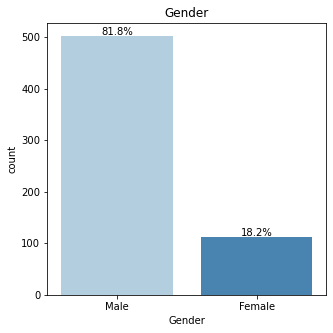

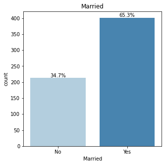

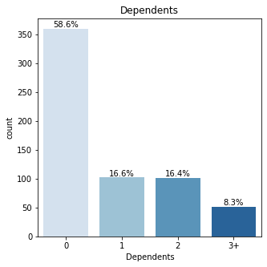

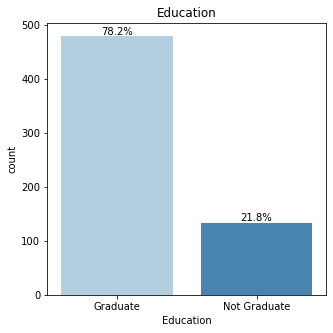

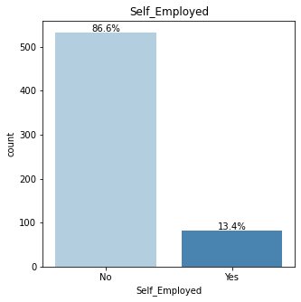

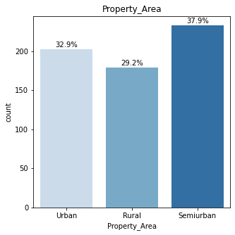

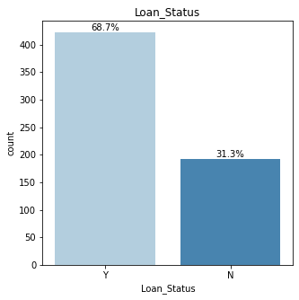

```python
#display the counts of observations using bars for each categorical column
for i in loan_cat:
    plt.figure(figsize=(5,5))
    total = float(len(loan_cat[i]))
    ax = sns.countplot(loan_cat[i],palette='Blues')
    for p in ax.patches:
        height = p.get_height()
        ax.text(p.get_x()+p.get_width()/2,height + 3,'{:.1f}%'.format(height/total*100),ha="center")
    ax.set_title(i)
    plt.show()
```

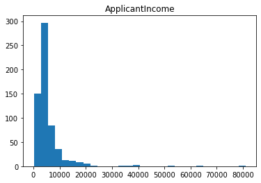

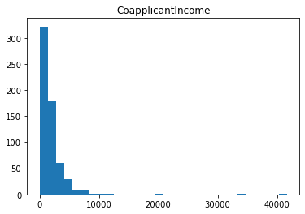

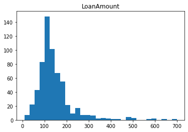

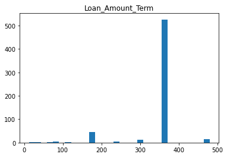

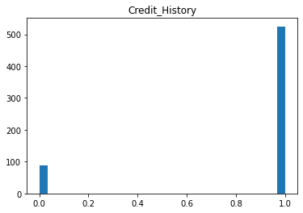

```python
#display the distribution of each numerical column
for i in loan_num:
    plt.hist(loan_num[i], bins=30)
    plt.title(i)
    plt.show()
```

Display categorical data by Loan status.

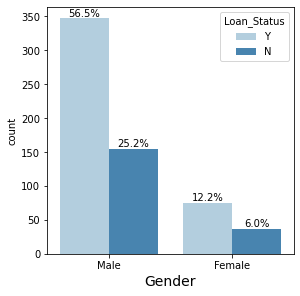

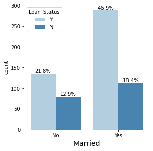

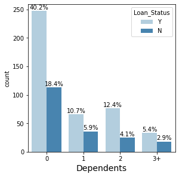

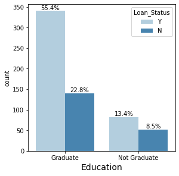

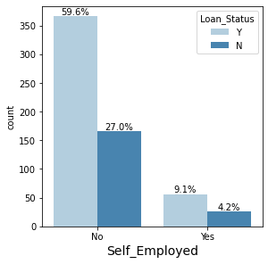

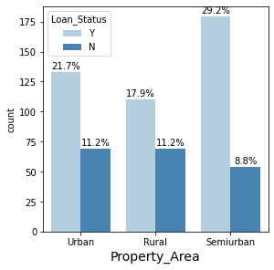

```python
for i in cat[:-1]:
    plt.figure(figsize=(15,10))
    total = float(len(loan_cat[i]))
    plt.subplot(2,3,1)
    ax=sns.countplot(x=i ,hue='Loan_Status', data=tr_df ,palette='Blues')
    plt.xlabel(i, fontsize=14)
    for p in ax.patches:
        height = p.get_height()
        ax.text(p.get_x()+p.get_width()/2,height + 3,'{:.1f}%'.format(height/total*100),ha="center")
```